# Time Series Regression: Part 3 Cointegration

PLSC 505

Professor Linn

March 15, 2022

# Preliminaries

In this help sheet, we will test for and estimate a cointegrating relationship between Stimson’s public policy mood, **Mood**, (higher values mean the public has a preference for more liberal social policies) and the economic portion of economic expectations, **filtbf** (predicted economic expectations based on inflation, unemployment and the coincident economic indicator index) and the generosity of public policy, **PolAvg** (based on average federal social spending, higher values are more generous).

Durr (1993) contends that Americans’ preference for a more or less activist federal government (**Mood**) is tied to expectations about the future of the economy (**filtbf**). When the public expects the future of the economy to be strong, producing jobs and tax revenues, it is willing to pay for the broadening of the social safety net for everyone. In contrast, visions of a gloomy economic future limit the desire for government spending to combat social ills. In addition, public preferences exhibit a thermostatic relationship with policy outcomes (**PolAvg**): the more liberal (expansive) policy is, the less of it the public will demand. Durr found each of these three time series to be unit root processes without drift or trend. His theoretical argument thus leads us to expect that while each is individually a unit root process, the stochastic trends in these variables are shared.

Ferguson, Kellstedt, and Linn (2015) extended Durr’s analysis and in what follows we will test Durr’s conjecture with the updated data.

Load packages.

```r
library(dynlm)  # To run dynamic LS
suppressPackageStartupMessages(library(stargazer)) # For table output
library(lmtest) # for LM tests
library(sandwich) # for various variance-covariance matrices
library(dplyr) # to manipulate data frames
library(ggplot2)
library(dplyr)
library(tidyr)
library(forecast) # for checkresiduals function
suppressPackageStartupMessages(source("PGTSadfv2.R"))
```

Read in the data, create **date** as date class, and filter to keep the first quarter of 1969 through the 4th quarter of 2010. The data is in the file “EconMood_v3.xls.”

```r
suppressPackageStartupMessages(library(gdata))
data = read.xls("EconMood_v3.xls")
data$date <- seq(as.Date("1968/4/1"), as.Date("2011/10/30"), by = "quarter")
data <- data %>%
  filter(date<="2010/10/1" & date>="1969/1/1")
```

We need either a ts class data object or a zoo class for the `dynlm()` function. I’ve done both here and will use the zoo class data frame in what follows. The advantage of zoo class is that you can add variables in the same manner as a data frame.

```r
data.ts <- ts(data, start = c(1969,1), end = c(2010, 3), frequency = 4)
data.ts2 <- as.zooreg(data.ts)
```

# Plot the Time Series

```r
df <- data %>%
  select(date, Mood, PolAvg, filtbf) %>%
  gather(key = "series", value = "value", -date)
```

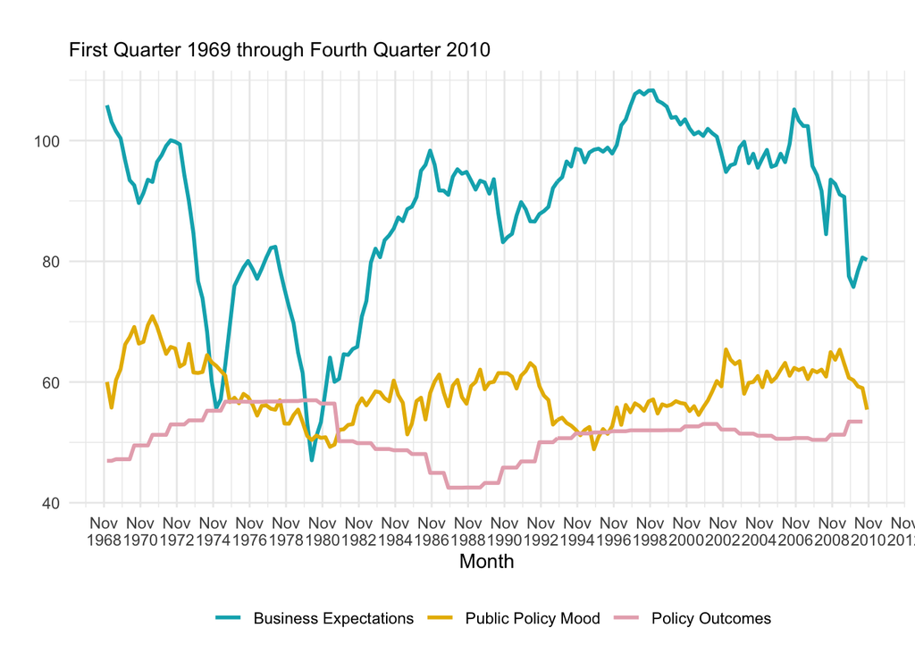

```r
ggplot(df, aes(x = date, y = value)) +
  geom_line(aes(color = series), size = 1) +
   scale_x_date(date_breaks = "24 month", date_labels = "%b\n%Y")+
  scale_color_manual(values = c("#00AFBB", "#E7B800","#E7AFBB", "#00B800"), name = "",
  labels =  c("Business Expectations", "Public Policy Mood", "Policy Outcomes")) +
  theme_minimal() +
  theme(legend.position="bottom") +
  labs(title="",
       x="Month",
       y="",
       subtitle="First Quarter 1969 through Fourth Quarter 2010")
```

Each of the series appears to deviate from its mean value for extended periods of time, suggestive of random walks. The figure might also suggest that public policy mood is in sync with economic expectations and inversely related to policy outcomes, as theorized.

# Conduct Unit Root Tests

Use the DF test to determine whether public policy mood (**Mood**), filetered business expectations (**filtbf**), and average liberalism of policy outcomes (**PolAvg**) are unit root processes.

## Is Mood a Unit Root Process?

Determine if **Mood** is a unit root process. I assume $D_t=c$, $pmax = 8$, and test for serial correlation over 12 lags.

```r
adf.tests(data$Mood, pmax = 8, lmtestorder = 12, type = "constant")
```

```
##
## Dickey Fuller Test Results -- Constant in Test Regression
## ======================================================================================
## Lags Test Statistic p-value   AIC     BIC   Diff t-value LM p-value Phi 1 Observations
## --------------------------------------------------------------------------------------
## 8        -2.708      0.075  657.555 691.313    0.670       0.127    3.808     159
## 7        -2.633      0.088  656.034 686.723    -1.341      0.665    3.606     159
## 6        -3.017      0.035  655.927 683.547    0.927       0.434    4.727     159
## 5        -2.890      0.049  654.829 679.380    1.556       0.442    4.350     159
## 4        -2.662      0.083  655.342 676.825    2.229       0.482    3.718     159
## 3        -2.416      0.139  658.423 676.837    -1.287      0.230    3.128     159
## 2        -2.580      0.099  658.125 673.470    -1.344      0.164    3.505     159
## 1        -2.784      0.063  657.968 670.243    -1.754      0.183    4.016     159
## 0        -3.165      0.024  659.073 668.280                0.177    5.119     159
## --------------------------------------------------------------------------------------
## [1] "Phi 1 Critical value .01: 6.52"
## [1] "Phi 1 Critical value .05: 4.63"
## [1] "Phi 1 Critical value .10: 3.81"
```

Choose $p$ for test regression.

- Could choose 4 based on the t-value on the highest lagged difference (2.229) and no serial correlation.
- Could choose 5 based on AIC and no serial correlation.
- Could choose 0 based only the absence of serial correlation.

Here I will estimate the model with $p=5$ to estimate with maximum sample size with 5 lags.

```r
adf.tests(data$Mood, pmax = 5, lmtestorder = 12, type = "constant")
```

```
##
## Dickey Fuller Test Results -- Constant in Test Regression
## ======================================================================================
## Lags Test Statistic p-value   AIC     BIC   Diff t-value LM p-value Phi 1 Observations
## --------------------------------------------------------------------------------------
## 5        -2.885      0.049  667.347 692.047    1.188       0.480    4.361     162
## 4        -2.706      0.075  666.815 688.428    2.556       0.428    3.854     162
## 3        -2.279      0.180  671.463 689.989    -1.199      0.175    2.767     162
## 2        -2.508      0.115  670.939 686.377    -1.110      0.136    3.310     162
## 1        -2.743      0.069  670.198 682.548    -1.826      0.143    3.916     162
## 0        -3.125      0.027  671.560 680.823                0.113    5.007     162
## --------------------------------------------------------------------------------------
## [1] "Phi 1 Critical value .01: 6.52"
## [1] "Phi 1 Critical value .05: 4.63"
## [1] "Phi 1 Critical value .10: 3.81"
```

This is as close as it gets. If we choose 5 lags, we can just reject the unit root null, but if we choose four we just fail to reject. We will proceed as if mood contains a unit root, although are classification of it as such comes with a lot of uncertainty. Rerunning with just one lag (the function doesn’t work with $pmax=0$ and the maximum sample size, we find that we cannot reject the unit root null.

```r
adf.tests(data$Mood, pmax = 1, lmtestorder = 12, type = "constant")
```

```
##
## Dickey Fuller Test Results -- Constant in Test Regression
## ======================================================================================
## Lags Test Statistic p-value   AIC     BIC   Diff t-value LM p-value Phi 1 Observations
## --------------------------------------------------------------------------------------
## 1        -2.454      0.129  696.457 708.905    -1.590      0.077    3.012     166
## 0        -2.858      0.053  697.012 706.348                0.059    4.085     166
## --------------------------------------------------------------------------------------
## [1] "Phi 1 Critical value .01: 6.52"
## [1] "Phi 1 Critical value .05: 4.63"
## [1] "Phi 1 Critical value .10: 3.81"
```

## Is PolAvg a Unit Root Process?

Determine if **PolAvg** is a unit root process. I again assume $D_t=c$, $pmax = 8$, and test for serial correlation over 12 lags.

```r
adf.tests(data$PolAvg, pmax = 8, lmtestorder=12, type="constant")
```

```
##
## Dickey Fuller Test Results -- Constant in Test Regression
## ======================================================================================
## Lags Test Statistic p-value   AIC     BIC   Diff t-value LM p-value Phi 1 Observations
## --------------------------------------------------------------------------------------
## 8        -2.281      0.179  349.831 383.519    2.082       0.786    2.626     159
## 7        -1.960      0.304  352.390 383.016    0.296       0.913    1.953     159
## 6        -1.944      0.312  350.483 378.046    0.281       0.922    1.921     159
## 5        -1.929      0.318  348.566 373.066    0.270       0.928    1.893     159
## 4        -1.916      0.324  346.642 368.080    5.974       0.936    1.868     159
## 3        -1.258      0.648  377.962 396.337    0.102       0.010    0.872     159
## 2        -1.258      0.648  375.972 391.285    0.121       0.010    0.873     159
## 1        -1.256      0.649  373.987 386.238    0.120       0.011    0.871     159
## 0        -1.255      0.650  372.002 381.190                0.011    0.869     159
## --------------------------------------------------------------------------------------
## [1] "Phi 1 Critical value .01: 6.52"
## [1] "Phi 1 Critical value .05: 4.63"
## [1] "Phi 1 Critical value .10: 3.81"
```

Choose $p$ for test regression.

- Could choose 8 based on the t-value on the highest lagged difference (2.082).
- Could choose 4 based on AIC.

Both have no evidence of serial correlation. Estimate the model with $p=4$ to estimate with maximum sample size with 4 lags.

```r
adf.tests(data$PolAvg, pmax = 4, lmtestorder=12, type="constant")
```

```
##
## Dickey Fuller Test Results -- Constant in Test Regression
## ======================================================================================
## Lags Test Statistic p-value   AIC     BIC   Diff t-value LM p-value Phi 1 Observations
## --------------------------------------------------------------------------------------
## 4        -2.117      0.238  359.688 381.301    5.983       0.919    2.358     163
## 3        -1.455      0.554  391.149 409.675    0.106       0.006    1.252     163
## 2        -1.456      0.553  389.161 404.599    0.110       0.006    1.254     163
## 1        -1.457      0.553  387.173 399.524    0.109       0.007    1.256     163
## 0        -1.458      0.552  385.185 394.448                0.007    1.258     163
## --------------------------------------------------------------------------------------
## [1] "Phi 1 Critical value .01: 6.52"
## [1] "Phi 1 Critical value .05: 4.63"
## [1] "Phi 1 Critical value .10: 3.81"
```

Whether we choose 4 or 8 lags, we fail to reject the null of a unit root.

## Is filtbf a Unit Root Process?

Determine if **filtbf** is a unit root process. If you assume $D_t=c$ $pmax = 8$, and test for serial correlation over 12 lags, you always reject the null of no serial correlation in the residuals. I’m going to use the Philips-Peron test, which should be robust to this problem.

```r
#adf.tests(data$filtbf, pmax = 23, lmtestorder=12, type="constant")
summary(ur.pp(data$filtbf, type = "Z-tau", mode = "constant", lags = "long"))
```

```
##
## ##################################
## # Phillips-Perron Unit Root Test #
## ##################################
##
## Test regression with intercept
##
##
## Call:
## lm(formula = y ~ y.l1)
##
## Residuals:
##      Min       1Q   Median       3Q      Max
## -12.9459  -1.3350   0.4118   1.7462   9.0564
##
## Coefficients:
##             Estimate Std. Error t value Pr(>|t|)
## (Intercept)  2.40718    1.56409   1.539    0.126
## y.l1         0.97121    0.01738  55.868   <2e-16 ***
## ---
## Signif. codes:  0 '***' 0.001 '**' 0.01 '*' 0.05 '.' 0.1 ' ' 1
##
## Residual standard error: 3.066 on 165 degrees of freedom
## Multiple R-squared:  0.9498, Adjusted R-squared:  0.9495
## F-statistic:  3121 on 1 and 165 DF,  p-value: < 2.2e-16
##
##
## Value of test-statistic, type: Z-tau  is: -2.1119
##
##          aux. Z statistics
## Z-tau-mu            2.0149
##
## Critical values for Z statistics:
##                      1pct      5pct     10pct
## critical values -3.470471 -2.878795 -2.575871
```

We fail to reject the unit root null: Z-tau = -2.1119, which is not further from zero than the 5pct critical value of -2.878795.

## Conclusions

We cannot reject the null hypothesis that each of these series are unit root processes, although it’s not clear if **Mood** is or is not a unit root process. We will consider this uncertainty later.

Assuming **Mood** is a unit root, we can test for cointegration. First, we will cover the Engle-Granger two-step approach and then the single-equation GECM approach.

# Engle-Granger Step 1

## Estimate a Cointegrating Regression

Based on Durr’s argument, we specify a cointegrating regression. Specifically, In Durr’s theory, the continual presence of societal problems and the public’s awareness that government’s ability to spend depends on tax revenues will prevent public policy mood from straying too far from economic expectations and policy outcomes so that any shocks to public policy mood will be temporary such that:

$$Mood_t = D_{lr} + \lambda_1 filtbf_t + \lambda_2 PolAvg_t + \mu_t$$

where $\mu_t$ must be stationary. If the error is $I(1)$, then public policy preferences would cumulate and deviations of **Mood** from **filtbf** and **PolAvg** would not be eliminated over time.

Before we estimate the cointegrating regression, we need to decide the appropriate form of deterministics in the model, $D_{lr}$. We want to include deterministics that affect the long-run relationship, i.e., how **Mood** evolves over time in relationship with **filtbf** and **PolAvg**.

- We don’t anticipate that in equilibrium the values of **Mood**, **filtbf**, and **PolAvg** are the same, thus we want to include a constant, $\lambda_0$, to allow there to be a mean difference between the series in equilibrium.
- A trend makes little sense (no series is drifting/trending), so we will not include it in the test regression.

$$Mood_t = \lambda_0 + \lambda_1 filtbf_t + \lambda_2 PolAvg_t + \mu_t$$

Estimate the cointegrating regression:

```r
mystatica <- dynlm(Mood ~ PolAvg +  filtbf, data=data.ts2)
summary(mystatica)
```

```
##
## Time series regression with "zooreg" data:
## Start = 1969 Q1, End = 2010 Q3
##
## Call:
## dynlm(formula = Mood ~ PolAvg + filtbf, data = data.ts2)
##
## Residuals:
##     Min      1Q  Median      3Q     Max
## -9.9283 -3.0260 -0.4014  2.7982 12.3030
##
## Coefficients:
##             Estimate Std. Error t value Pr(>|t|)
## (Intercept) 65.31137    6.40995  10.189   <2e-16 ***
## PolAvg      -0.22701    0.09883  -2.297   0.0229 *
## filtbf       0.05285    0.02712   1.949   0.0530 .
## ---
## Signif. codes:  0 '***' 0.001 '**' 0.01 '*' 0.05 '.' 0.1 ' ' 1
##
## Residual standard error: 4.38 on 164 degrees of freedom
## Multiple R-squared:  0.08442,    Adjusted R-squared:  0.07326
## F-statistic: 7.561 on 2 and 164 DF,  p-value: 0.0007227
```

**Remember: We cannot conduct hypothesis tests on individual coefficients in this regression!**

## Test Residuals for Cointegration

Having estimated the cointegrating regression, our next task is to determine whether the residuals are stationary. If they are, then **Mood** is cointegrated with at least one of the two $I(1)$ regressors (**filtbf** and/or **PolAvg**). Thus, we test for cointegration using a unit root test applied to the residuals from the cointegrating regression. We will use a Dickey-Fuller test, but we could use other unit root tests as well.

Remember that we do not include a constant or trend in the DF test regression because the residuals have a mean of zero and there is no trend. I choose $pmax=12$ for the test and test for serial correlation up through 12 lags. *Note* The test statistic in this output does *not* follow the Dickey-Fuller distribution, so we cannot use the p-values from the `adf.tests()` function. The test statistic is still the $t$-value on lagged $\hat{\mu}$. We are just using the Dickey Fuller test to select the number of lags, $p$, for the test regression and then get the test statistic from that regression.

```r
adf.tests(mystatica$residuals, pmax = 12, lmtestorder = 12, type = "none")
```

```
##
## Dickey Fuller Test Results -- No Constant or Trend in Test Regression
## =========================================================================
## Lags Test Statistic p-value   AIC     BIC   Diff t LM pvalue Observations
## -------------------------------------------------------------------------
## 12       -2.349      0.158  631.877 674.394 1.105    0.428       154
## 11       -2.208      0.204  631.205 670.685 -1.269   0.384       154
## 10       -2.487      0.121  630.942 667.385 -0.498   0.468       154
## 9        -2.620      0.091  629.209 662.615 0.358    0.522       154
## 8        -2.604      0.094  627.346 657.715 0.771    0.498       154
## 7        -2.540      0.108  625.975 653.308 -2.328   0.881       154
## 6        -2.900      0.048  629.590 653.886 0.216    0.580       154
## 5        -2.908      0.047  627.639 648.898 0.768    0.635       154
## 4        -2.829      0.057  626.251 644.473 1.750    0.626       154
## 3        -2.640      0.087  627.383 642.568 -1.459   0.458       154
## 2        -2.811      0.059  627.553 639.701 -1.255   0.364       154
## 1        -2.993      0.038  627.152 636.262 -2.093   0.365       154
## -------------------------------------------------------------------------
```

Seven lags seems a good choice based both on the AIC and the t-statistic on the highest lagged difference. I rerun the test with $pmax=7$ to estimate the regression with the maximum number of observations and obtain the test statistic.

```r
adf.tests(mystatica$residuals, pmax = 7, lmtestorder = 12, type = "none")
```

```
##
## Dickey Fuller Test Results -- No Constant or Trend in Test Regression
## =========================================================================
## Lags Test Statistic p-value   AIC     BIC   Diff t LM pvalue Observations
## -------------------------------------------------------------------------
## 7        -2.383      0.148  648.892 676.513 -1.640   0.874       159
## 6        -2.799      0.061  649.700 674.251 0.623    0.556       159
## 5        -2.734      0.071  648.106 669.588 1.168    0.577       159
## 4        -2.554      0.105  647.517 665.930 1.962    0.586       159
## 3        -2.279      0.180  649.442 664.787 -1.617   0.402       159
## 2        -2.517      0.113  650.103 662.379 -1.494   0.248       159
## 1        -2.779      0.064  650.361 659.568 -1.968   0.260       159
## -------------------------------------------------------------------------
```

The value of our test statistic is -2.383.

### Critical values of Dickey Fuller Test

We will use the 0.05 critical value.

## Estimate the Cointegrating Regression with Interventions

The values used for the intervention variables are given below.

- Values of **Vietnam**: 0, 0.03, 0.06, 0.09, 0.15, 0.24, 0.39, 0.64, 1, 1, 1, 1, 1, 1 (through 1975), 0, 0, 0 after. The idea here is that Vietnam became more relevant over time as more and more Americans were killed and shifted the mean of any long-run relationship.
- Values of **Iraq**: 0 before first quarter 2003 and 1 after. The Iraq war was not over by the end of the sample, so this allows the mean of any long-run relationship to change during the war.
- Values of **IranHost**: 0 before fourth quarter 1979, then 1 for 6 quarters and then 0.64, 0.39, 0.24, 0.15, 0.09, 0.06, 0.03, then 0 after.

Let’s estimate the cointegrating regression with these intervention variables:

```r
mystatic <- dynlm(Mood ~ PolAvg +  filtbf + IranHost + Vietnam + Iraq, data = data.ts2)
summary(mystatic)
```

```
##
## Time series regression with "zooreg" data:
## Start = 1969 Q1, End = 2010 Q3
##
## Call:
## dynlm(formula = Mood ~ PolAvg + filtbf + IranHost + Vietnam +
##     Iraq, data = data.ts2)
##
## Residuals:
##     Min      1Q  Median      3Q     Max
## -7.0068 -1.6272  0.2213  1.3869  6.3581
##
## Coefficients:
##             Estimate Std. Error t value Pr(>|t|)
## (Intercept) 77.88975    3.83030  20.335  < 2e-16 ***
## PolAvg      -0.34983    0.05920  -5.910 1.98e-08 ***
## filtbf      -0.04012    0.01858  -2.159   0.0323 *
## IranHost    -5.56080    1.25327  -4.437 1.68e-05 ***
## Vietnam      9.56947    0.63668  15.030  < 2e-16 ***
## Iraq         5.54207    0.53350  10.388  < 2e-16 ***
## ---
## Signif. codes:  0 '***' 0.001 '**' 0.01 '*' 0.05 '.' 0.1 ' ' 1
##
## Residual standard error: 2.553 on 161 degrees of freedom
## Multiple R-squared:  0.6945, Adjusted R-squared:  0.685
## F-statistic: 73.19 on 5 and 161 DF,  p-value: < 2.2e-16
```

**Remember: We cannot conduct hypothesis tests on individual coefficients in this regression!**

## Test Residuals for Cointegration

Now we conduct a test of the null hypothesis of no cointegration using a Dickey Fuller test applied to the residuals from this regression:

```r
adf.tests(mystatic$residuals, pmax = 12, lmtestorder = 12, type = "none")
```

```
##
## Dickey Fuller Test Results -- No Constant or Trend in Test Regression
## =========================================================================
## Lags Test Statistic p-value   AIC     BIC   Diff t LM pvalue Observations
## -------------------------------------------------------------------------
## 12       -3.303      0.016  638.993 681.511 0.422    0.219       154
## 11       -3.316      0.016  637.187 676.668 -0.840   0.205       154
## 10       -3.738      0.004  635.950 672.394 0.157    0.248       154
## 9        -3.880      0.003  633.977 667.384 0.752    0.246       154
## 8        -3.833      0.003  632.580 662.950 0.968    0.244       154
## 7        -3.710      0.005  631.572 658.905 -1.411   0.494       154
## 6        -4.433        0    631.658 655.953 1.266    0.281       154
## 5        -4.242      0.001  631.327 652.586 0.319    0.299       154
## 4        -4.401        0    629.433 647.655 2.359    0.444       154
## 3        -3.824      0.003  633.080 648.265 -1.063   0.276       154
## 2        -4.420        0    632.235 644.383 0.418    0.190       154
## 1        -4.556        0    630.413 639.523 -0.905   0.213       154
## -------------------------------------------------------------------------
```

It looks like $p=4$, based on the AIC, the value of the highest first-difference in the test regression (2.359), although the test regression with $p=1$ also shows no evidence of serial correlation. We will calculate the value of the test statistic for $p=4$.

```r
adf.tests(mystatic$residuals, pmax = 4, lmtestorder = 12, type = "none")
```

```
##
## Dickey Fuller Test Results -- No Constant or Trend in Test Regression
## =========================================================================
## Lags Test Statistic p-value   AIC     BIC   Diff t LM pvalue Observations
## -------------------------------------------------------------------------
## 4        -4.417        0    662.129 680.654 2.474    0.832       162
## 3        -3.806      0.003  666.323 681.761 -1.333   0.431       162
## 2        -4.530        0    666.134 678.484 0.377    0.372       162
## 1        -4.710        0    664.279 673.542 -0.917   0.441       162
## -------------------------------------------------------------------------
```

The value of the test statistic is -4.417.

### Critical values of Dickey Fuller Test with Interventions

We cannot use the MacKinnon tables to calculate the appropriate critical value, as the tables do not allow for interventions. Instead, we need to simiulate them. We do so by following these steps:

1. Simulate $n-1$ unit root processes of length $T$, without a constant. Here we need to simulate two random walks without drift.
2. Generate the first differences of the intervention variables in $D_{lr}$ used in the test regression. (If none, we have the MacKinnon case.)
3. Simulate $y_t$ as an $I(1)$ variable without a constant and as a function of the first differences of the intervention variables in $D_{lr}$ *but not* $\mathbf{X_t}$. (We always generate critical values under the null hypothesis, so that the series are unrelated in the long-run.) This creates a permanent change in $y_t$ with each increment of the differenced intervention. Put differently, we use first difference interventions because y is a unit root and thus permanently incorporates the shocks. Again, if there are no interventions, we have the MacKinnon case.)
4. Regress $y_t$on $D_{lr}$ (not the first differences of interventions) and $\mathbf{X_t}$ and save the residuals. We estimate the cointegrating regression with the original interventions, which causes mean shifts in any cointegrating relationship. (If no interventions, simulate $y_t$ omitting the interventions. Again, the MacKinnon case.)
5. Conduct a unit root test on the residuals and save the test statistic.
6. Repeat a large number of times, say 50,000.
7. Calculate the desired percentile from the resulting distribution of the test statistic. This is the critical value for the test.
8. Compare the critical value with the sample statistic in your cointegrating regression and draw an inference.

*Note* if the individual series in our analysis contained drift, we would simulate the variables with a constant and then add a trend to the cointegrating regression.

#### First, I’m going to create functions to use in the simulations.

- tslag: to lag a variable and add NA to the first observation, so the number of observations stays constant.
- tsdiff: to first difference a variable and add NA to the first observation so that the number of observations is unchanged.
- gen.unit.root: to generate a unit root without drift or trend
- gen.y: to generate a unit root without drift or trend with three intervention variables

```r
set.seed(19852015)
tslag<-function(y,d=1){
  n<-length(y)
  c(rep(NA,d),y)[1:n]
}

tsdiff <- function(y, d = 1){
  n <- length(y)

  c(rep(NA,d),diff(y))[1:n]

}

gen.unit.root <- function(n){

  e.x <- rnorm(n)
  x <- double(n)
  x[1] <- rnorm(1)
  for(i in 2:n){
    x[i] <- x[i-1] + e.x[i]
  }
  x
}
gen.y <- function(n, var1, var2, var3){
  #set.seed(19852015)
  e.y <- rnorm(n)
  y <- double(n)
  y[1] <- rnorm(1)
  for(i in 2:n){
    y[i] <- y[i-1] +var1[i] + var2[i] + var3[i] +  e.y[i]
  }
  y
}
```

#### Generate MacKinnon Critical Value for the Dickey Fuller Test with a Constant

Let’s first replicate the case with no interventions and compare to the appropriate MacKinnon table. To approximate the asymptotic critical values for the DF test, I generate time series with 15000 observations. Here I’m only going to use 10,000 replications as this takes a long time to run.

```r
dfuller.valuesM <- function(nsim,T){
    pb <- txtProgressBar(min = 0,      # Minimum value of the progress bar
                     max = nsim, # Maximum value of the progress bar
                     style = 3,    # Progress bar style (also available style = 1 and style = 2)
                     width = 50,   # Progress bar width. Defaults to getOption("width")
                     char = "=")   # Character used to create the bar

  out <- vector(mode="list", length=nsim)
  for(m in 1:nsim){
x1 <-  gen.unit.root(n=T)  # Generate x1 as a unit root
x2 <-  gen.unit.root(n=T)  # Generate x2 as a unit root
y <- gen.unit.root(n=T)    # Generate y as a unit root
lm.df <- summary(lm(y~ x1 + x2)) #Estimate the cointegrating regression with a constant
muhat <- lm.df$residuals         #Harvest the residuals
mu.diff <- tsdiff(muhat)   #First difference the residual for dependent variable in DF test
    lag.mu <- tslag(muhat)          #Lag the residuals for DF test
    lm.df <- summary(lm(mu.diff~lag.mu -1))  #Estimate test regression without a constant
    t.df <- lm.df$coefficients[,3][[1]]      #Harvest the t-statistic from the results
    out[[m]] <- t.df                         #Add the t-statistic to out
 # setTxtProgressBar(pb, m)
  }
  unlist(out)
}

outM <- dfuller.valuesM(nsim=10000, T=15000)
```

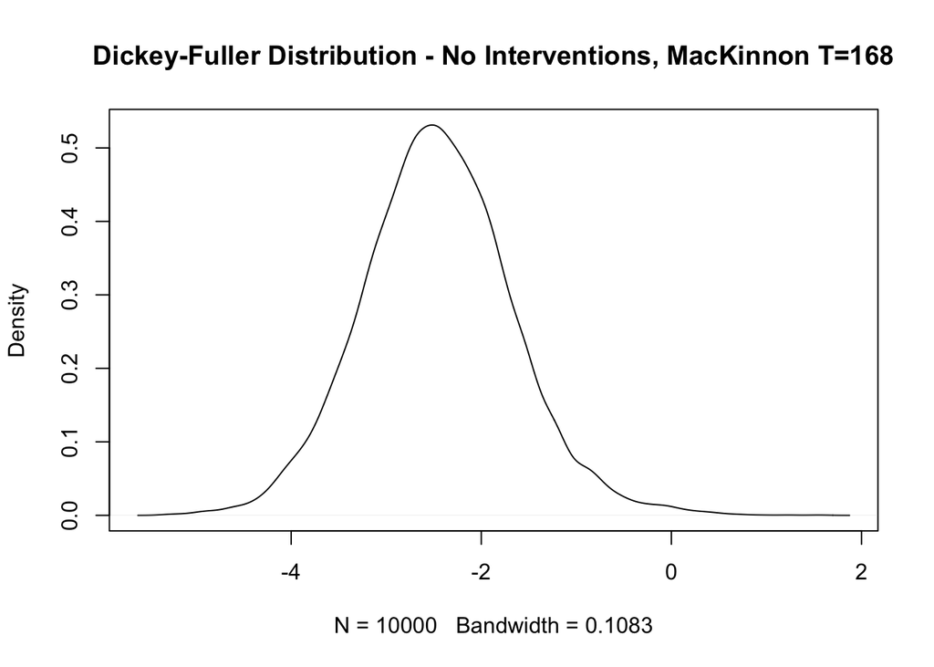

```r
plot(density(unlist(outM)),main="Dickey-Fuller Distribution - No Interventions, MacKinnon T=168")
```

```r
DF.MacKinnon <- quantile(outM,c(.01,.025,.05,.1))
DF.MacKinnon
```

```
##        1%      2.5%        5%       10%
## -4.255740 -3.979411 -3.724672 -3.442781
```

We estimate a 5% critical value of -3.724672. This is pretty close to the asymptotic MacKinnon value of −3.74066.

#### Generate Critical Values for Dickey Fuller Test given our interventions

Now we set T=168 and add the interventions to obtain critical values appropriate for our example analysis. Here we can do more simulations and not add significantly to the time to run.

```r
dfuller.valuesMood <- function(nsim, T){
    pb <- txtProgressBar(min = 0,      # Minimum value of the progress bar
                     max = nsim, # Maximum value of the progress bar
                     style = 3,    # Progress bar style (also available style = 1 and style = 2)
                     width = 50,   # Progress bar width. Defaults to getOption("width")
                     char = "=")   # Character used to create the bar

  out <- vector(mode="list", length=nsim)
  for(m in 1:nsim){
x1 <-  gen.unit.root(n=T)  # Generate x1 as a unit root
x2 <-  gen.unit.root(n=T1)  # Generate x2 as a unit root
Vietnam <- data$Vietnam[1:T] # Grab the interventions from the data
Hostages <- data$IranHost[1:T]
Iraq <- data$Iraq[1:T]
  V.diff <- tsdiff(Vietnam) #First difference the interventions
  H.diff <- tsdiff(Hostages)
  I.diff <- tsdiff(Iraq)
y <- gen.y(T, V.diff, H.diff, I.diff)    # Generate y as a unit root plus the differenced interventions
lm.df <- summary(lm(y~ x1 + x2 + Vietnam + Hostages + Iraq)) #Estimate the cointegrating regression with a constant and levels of the interventions
muhat <- lm.df$residuals         #Harvest the residuals
mu.diff <- tsdiff(muhat)   #First difference the residual for dependent variable in DF test
    lag.mu <- tslag(muhat)          #Lag the residuals for DF test
    lm.df <- summary(lm(mu.diff~lag.mu -1))  #Estimate test regression without a constant
    t.df <- lm.df$coefficients[,3][[1]]      #Harvest the t-statistic from the results
    out[[m]] <- t.df
    #setTxtProgressBar(pb, m)
  }
  unlist(out)
}

outMood <- dfuller.valuesM(50000, T=168)
```

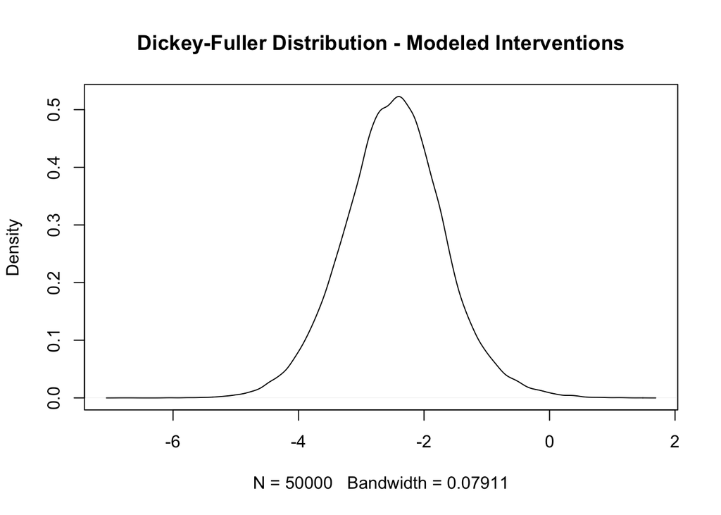

```r
plot(density(unlist(outMood)),main="Dickey-Fuller Distribution - Modeled Interventions")
```

```r
DF.MacKinnon <- quantile(outMood,c(.01,.025,.05,.1))
DF.MacKinnon
```

```
##        1%      2.5%        5%       10%
## -4.413878 -4.074405 -3.803323 -3.492676
```

The critical values shifted a small amount to the left and is now -3.803323, making it more difficult to reject the null of no cointegration. However, the test statistic value from above is -4.417, which is further from zero. Therefore we reject the null hypothesis of no cointegration.

## Dynamic OLS

If you reject the null of no cointegration, you need to ask which variables are part of the cointegrating relationship? You can use DOLS to answer this question. DOLS adds leads and lags of the regressors in first differences to the static cointegrating regression.

$$y_t = D_{lr} + \lambda_{1} x_{1t} + \lambda_{2} x_{2t} + ...+\lambda_{n} x_{nt} + \sum_{j=1}^n \sum_{s=1}^r \eta_{js} \Delta x_{jt\pm s} +\mu_t$$

where $r$ is large enough to ensure the regressors are not correlated with the error. Including the additional lag and lead terms soaks up the long-run correlation between the regressors and the errors. As a result, the bias in the estimates of the long-run relationship tend to be smaller in DOLS than in the static cointegrating regression. Moreover, we can test restrictions on the cointegrating vector using Newey-West heteroscedastic and autocorrelation consistent standard errors.

I’ve estimated this equation setting $r=2$ and $r=4$.

```r
myDOLS<- dynlm(Mood~  PolAvg +  L(d(PolAvg),c(-1, -2, 1, 2)) + filtbf + L(d(filtbf),c(-1, -2, 1, 2)) +  IranHost + Vietnam + Iraq, data=data.ts2)

myDOLSHAC <- coeftest(myDOLS, vcov = vcovHAC(myDOLS))
```

```r
myDOLS2<- dynlm(Mood~ PolAvg +  filtbf + IranHost + Vietnam + Iraq + L(d(PolAvg),c(-1, -2, -3, -4, 1, 2,3,4)) + L(d(filtbf),c(-1, -2, -3, -4, 1, 2,3,4)), data=data.ts2)
myDOLSHAC2 <- coeftest(myDOLS2, vcov = vcovHAC(myDOLS2))

stargazer(myDOLSHAC, myDOLSHAC2, type = "text")
```

```
##
## ==========================================================================
##                                                   Dependent variable:
##                                               ----------------------------
##
##                                                    (1)            (2)
## --------------------------------------------------------------------------
## PolAvg                                          -0.342***      -0.367***
##                                                  (0.096)        (0.090)
##
## L(d(PolAvg), c(-1, -2, 1, 2))-1                  0.664***
##                                                  (0.196)
##
## L(d(PolAvg), c(-1, -2, 1, 2))-2                   0.435*
##                                                  (0.226)
##
## L(d(PolAvg), c(-1, -2, 1, 2))1                    0.394
##                                                  (0.273)
##
## L(d(PolAvg), c(-1, -2, 1, 2))2                    0.267
##                                                  (0.311)
##
## filtbf                                            -0.044        -0.055
##                                                  (0.039)        (0.041)
##
## L(d(filtbf), c(-1, -2, 1, 2))-1                   0.018
##                                                  (0.064)
##
## L(d(filtbf), c(-1, -2, 1, 2))-2                   0.002
##                                                  (0.092)
##
## L(d(filtbf), c(-1, -2, 1, 2))1                    0.025
##                                                  (0.057)
##
## L(d(filtbf), c(-1, -2, 1, 2))2                    -0.030
##                                                  (0.071)
##
## IranHost                                        -5.080***      -5.282***
##                                                  (1.402)        (1.391)
##
```

[output cut: 45 more lines]

```
## L(d(filtbf), c(-1, -2, -3, -4, 1, 2, 3, 4))2                    -0.021
##                                                                 (0.073)
##
## L(d(filtbf), c(-1, -2, -3, -4, 1, 2, 3, 4))3                    -0.030
##                                                                 (0.081)
##
## L(d(filtbf), c(-1, -2, -3, -4, 1, 2, 3, 4))4                    -0.091
##                                                                 (0.068)
##
## Constant                                        77.811***      80.063***
##                                                  (6.690)        (6.664)
##
## ==========================================================================
## ==========================================================================
## Note:                                          *p<0.1; **p<0.05; ***p<0.01
```

We can use these t-tests to test whether the levels variables and interventions enter the long run relationship. The results suggest **filtbf** is not part of the cointegerating relationship, whether $r=2$ or $r=4$. (I also tried 8 and the results are the same.) Let’s reestimate the static cointegrating regression without this variable and test for cointegration again.

```r
mystatic2 <- dynlm(Mood~ PolAvg + IranHost + Vietnam + Iraq, data=data.ts2)
summary(mystatic2)
```

```
##
## Time series regression with "zooreg" data:
## Start = 1969 Q1, End = 2010 Q3
##
## Call:
## dynlm(formula = Mood ~ PolAvg + IranHost + Vietnam + Iraq, data = data.ts2)
##
## Residuals:
##     Min      1Q  Median      3Q     Max
## -7.4007 -1.4577  0.1525  1.3509  7.5452
##
## Coefficients:
##             Estimate Std. Error t value Pr(>|t|)
## (Intercept) 72.37470    2.88658  25.073  < 2e-16 ***
## PolAvg      -0.31193    0.05717  -5.456 1.79e-07 ***
## IranHost    -4.25957    1.11124  -3.833 0.000181 ***
## Vietnam      9.51837    0.64339  14.794  < 2e-16 ***
## Iraq         5.33618    0.53081  10.053  < 2e-16 ***
## ---
## Signif. codes:  0 '***' 0.001 '**' 0.01 '*' 0.05 '.' 0.1 ' ' 1
##
## Residual standard error: 2.582 on 162 degrees of freedom
## Multiple R-squared:  0.6856, Adjusted R-squared:  0.6779
## F-statistic: 88.32 on 4 and 162 DF,  p-value: < 2.2e-16
```

```r
adf.tests(mystatic2$residuals, lmtestorder = 12, pmax=4, type = "none")
```

```
##
## Dickey Fuller Test Results -- No Constant or Trend in Test Regression
## =========================================================================
## Lags Test Statistic p-value   AIC     BIC   Diff t LM pvalue Observations
## -------------------------------------------------------------------------
## 4        -4.323      0.001  659.407 677.933 2.577    0.848       162
## 3        -3.685      0.005  664.120 679.558 -1.473   0.423       162
## 2        -4.412        0    664.329 676.680 0.313    0.330       162
## 1        -4.594        0    662.429 671.692 -0.956   0.405       162
## -------------------------------------------------------------------------
```

The only change to our previous simulation is that we drop x2 from the simulation and generate the critical value.

```r
dfuller.valuesMood <- function(nsim, T){
    pb <- txtProgressBar(min = 0,      # Minimum value of the progress bar
                     max = nsim, # Maximum value of the progress bar
                     style = 3,    # Progress bar style (also available style = 1 and style = 2)
                     width = 50,   # Progress bar width. Defaults to getOption("width")
                     char = "=")   # Character used to create the bar

  out <- vector(mode="list", length=nsim)
  for(m in 1:nsim){
x1 <-  gen.unit.root(n=T)  # Generate x1 as a unit root
Vietnam <- data$Vietnam[1:T] # Grab the interventions from the data
Hostages <- data$IranHost[1:T]
Iraq <- data$Iraq[1:T]
  V.diff <- tsdiff(Vietnam) #First difference the interventions
  H.diff <- tsdiff(Hostages)
  I.diff <- tsdiff(Iraq)
y <- gen.y(T, V.diff, H.diff, I.diff)    # Generate y as a unit root plus the differenced interventions
lm.df <- summary(lm(y~ x1 + Vietnam + Hostages + Iraq)) #Estimate the cointegrating regression with a constant and levels of the interventions
muhat <- lm.df$residuals         #Harvest the residuals
mu.diff <- tsdiff(muhat)   #First difference the residual for dependent variable in DF test
    lag.mu <- tslag(muhat)          #Lag the residuals for DF test
    lm.df <- summary(lm(mu.diff~lag.mu -1))  #Estimate test regression without a constant
    t.df <- lm.df$coefficients[,3][[1]]      #Harvest the t-statistic from the results
    out[[m]] <- t.df
    #setTxtProgressBar(pb, m)
  }
  unlist(out)
}

outMood <- dfuller.valuesM(50000, T=168)
```

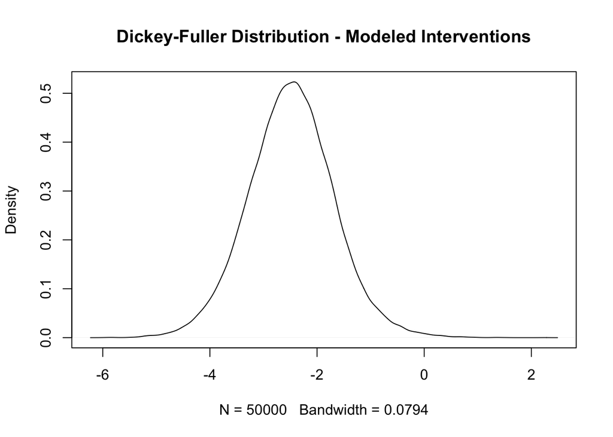

```r
plot(density(unlist(outMood)),main="Dickey-Fuller Distribution - Modeled Interventions")
```

```r
DF.MacKinnon <- quantile(outMood,c(.01,.025,.05,.1))
DF.MacKinnon
```

```
##        1%      2.5%        5%       10%
## -4.382907 -4.064461 -3.790572 -3.487998
```

The 5% critical value is -3.790572 and the value of the test statistic is -4.323, so we can again reject the null of no cointegration.

We can calculate the disequilibrium from this regression or simply save the residuals. I’m going to save the residuals as **static.DISEQ** in data.ts2, our zoo class data frame.

$y_{t-1} - D_{lr} + \lambda_{1} x_{1t} + \lambda_{2} x_{2t} + ...+ \lambda_{n} x_{nt}$

```r
data.ts2$static.DISEQ <- mystatic2$residuals
```

We can compare this to the disequilibrium from a respecified (without **filtbf**) DOLS, where the disequilibrium is calculated exactly as above, i.e., ignoring the differenced terms.

$y_{t-1} - D_{lr} + \lambda_{1} x_{1t} + \lambda_{2} x_{2t} + ...+ \lambda_{n} x_{nt}$

```r
myDOLS3<- dynlm(Mood~ PolAvg  + IranHost + Vietnam + Iraq + L(d(PolAvg),-1) + L(d(PolAvg),1)+ L(d(PolAvg),-2) + L(d(PolAvg),2) + L(d(PolAvg),-3) + L(d(PolAvg),3)+ L(d(PolAvg),-4) + L(d(PolAvg),4), data=data.ts)
myDOLSHAC3<- coeftest(myDOLS3, vcov = vcovHAC(myDOLS3))
stargazer(myDOLSHAC3, type = "text")
```

```
##
## ============================================
##                      Dependent variable:
##                  ---------------------------
##
## --------------------------------------------
## PolAvg                    -0.311***
##                            (0.100)
##
## IranHost                  -2.855**
##                            (1.252)
##
## Vietnam                   8.332***
##                            (1.526)
##
## Iraq                      5.540***
##                            (0.723)
##
## L(d(PolAvg), -1)          0.652***
##                            (0.224)
##
## L(d(PolAvg), 1)            0.409*
##                            (0.227)
##
## L(d(PolAvg), -2)           0.485**
##                            (0.240)
##
## L(d(PolAvg), 2)             0.230
##                            (0.274)
##
## L(d(PolAvg), -3)            0.134
##                            (0.198)
##
## L(d(PolAvg), 3)             0.197
##                            (0.307)
##
## L(d(PolAvg), -4)           0.470*
##                            (0.243)
##
## L(d(PolAvg), 4)             0.426
##                            (0.367)
##
## Constant                  72.324***
##                            (4.796)
##
## ============================================
## ============================================
## Note:            *p<0.1; **p<0.05; ***p<0.01
```

You can ignore the warning message in the code below. This code saves the disequilibrium from the DOLS regression as **DOLS.DISEQ**.

```r
data.ts2$DOLS.DISEQ <- data.ts2$Mood -(myDOLS3$coefficients[1] + myDOLS3$coefficients[2]*data$PolAvg+ myDOLS3$coefficients[3]*data$IranHost + myDOLS3$coefficients[4]*data$Vietnam + myDOLS3$coefficients[5]*data$Iraq)
```

```
## Warning in `-.default`(data.ts2$Mood, (myDOLS3$coefficients[1] +
## myDOLS3$coefficients[2] * : longer object length is not a multiple of shorter
## object length
```

Now let’s check the correlation between the two measures of disequilibrium and plot the disequilibrium.

```r
cor(data.ts2$DOLS.DISEQ, data.ts2$static.DISEQ, use = "pairwise.complete.obs")
```

```
## [1] 0.9811973
```

Almost the same! Let’s plot the disequilibrium:

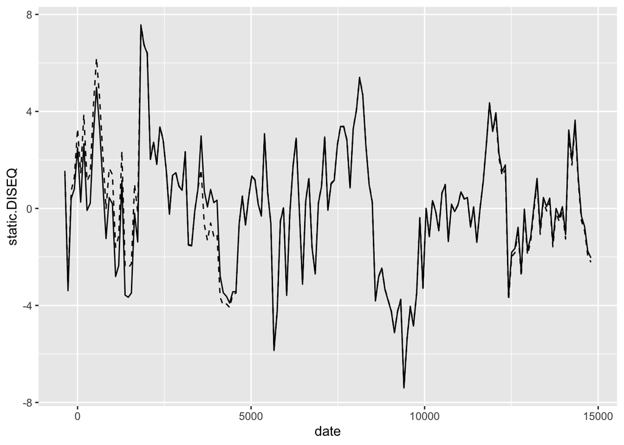

```r
ggplot(data.ts2, aes (x = date, y = static.DISEQ)) +
  geom_line()+
  geom_line(aes(x = date, y = DOLS.DISEQ), linetype = 2)
```

Notice that the disequilibrium ($\hat{\mu}$) looks stationary as it should.

# Engle-Granger Step 2

Cointegration implies that the any disequilibrium should drive **Mood** to change to restore the long-run cointegrating relationship/equilibrium. Thus, in step two we estimate an error correction model in which changes in **Mood** are a function of the long-run disequilibrium in the previous period, $\hat{\mu}_t$ and contemporaneous changes in the independent variables. The form of this regression is an ECM.

Before we estimate the ECM, we need to determine $D_{sr}$. We want to allow for the events to have a temporary effect on $\Delta y_t$, so we enter the first-differenced interventions in step two.

We’ll also test for serial correlation in the residuals, but it is important to note that this regression should meet all the TS regression assumptions.

```r
second.step <- dynlm(d(Mood)~ L(DOLS.DISEQ)  + d(Vietnam) + d(IranHost) + d(Iraq) +  d(PolAvg) + d(filtbf)+  L(d(PolAvg),1) + L(d(filtbf),1) + L(d(Mood),1) + L(d(Mood),4)+ L(d(Mood),8), data=data.ts2)
summary(second.step)
```

```
##
## Time series regression with "zooreg" data:
## Start = 1971 Q2, End = 2010 Q3
##
## Call:
## dynlm(formula = d(Mood) ~ L(DOLS.DISEQ) + d(Vietnam) + d(IranHost) +
##     d(Iraq) + d(PolAvg) + d(filtbf) + L(d(PolAvg), 1) + L(d(filtbf),
##     1) + L(d(Mood), 1) + L(d(Mood), 4) + L(d(Mood), 8), data = data.ts2)
##
## Residuals:
##     Min      1Q  Median      3Q     Max
## -5.8913 -0.9141  0.0678  1.0221  3.4888
##
## Coefficients:
##                 Estimate Std. Error t value Pr(>|t|)
## (Intercept)     -0.07816    0.13543  -0.577   0.5648
## L(DOLS.DISEQ)   -0.29408    0.05856  -5.022 1.47e-06 ***
## d(Vietnam)       0.41175    1.75471   0.235   0.8148
## d(IranHost)     -0.37085    1.57943  -0.235   0.8147
## d(Iraq)          6.98120    1.73983   4.013 9.56e-05 ***
## d(PolAvg)       -0.08442    0.18001  -0.469   0.6398
## d(filtbf)        0.04170    0.04697   0.888   0.3760
## L(d(PolAvg), 1) -0.09014    0.18804  -0.479   0.6324
## L(d(filtbf), 1) -0.03754    0.04788  -0.784   0.4343
## L(d(Mood), 1)   -0.03617    0.07631  -0.474   0.6362
## L(d(Mood), 4)    0.15516    0.07276   2.132   0.0346 *
## L(d(Mood), 8)    0.10098    0.07125   1.417   0.1585
## ---
## Signif. codes:  0 '***' 0.001 '**' 0.01 '*' 0.05 '.' 0.1 ' ' 1
##
## Residual standard error: 1.689 on 146 degrees of freedom
## Multiple R-squared:  0.2939, Adjusted R-squared:  0.2407
## F-statistic: 5.523 on 11 and 146 DF,  p-value: 2.397e-07
```

```r
bgtest(second.step, order=4)
```

```
##
##  Breusch-Godfrey test for serial correlation of order up to 4
##
## data:  second.step
## LM test = 4.2346, df = 4, p-value = 0.3752
```

```r
bgtest(second.step, order=8)
```

```
##
##  Breusch-Godfrey test for serial correlation of order up to 8
##
## data:  second.step
## LM test = 10.206, df = 8, p-value = 0.2508
```

```r
bgtest(second.step, order=12)
```

```
##
##  Breusch-Godfrey test for serial correlation of order up to 12
##
## data:  second.step
## LM test = 13.815, df = 12, p-value = 0.3127
```

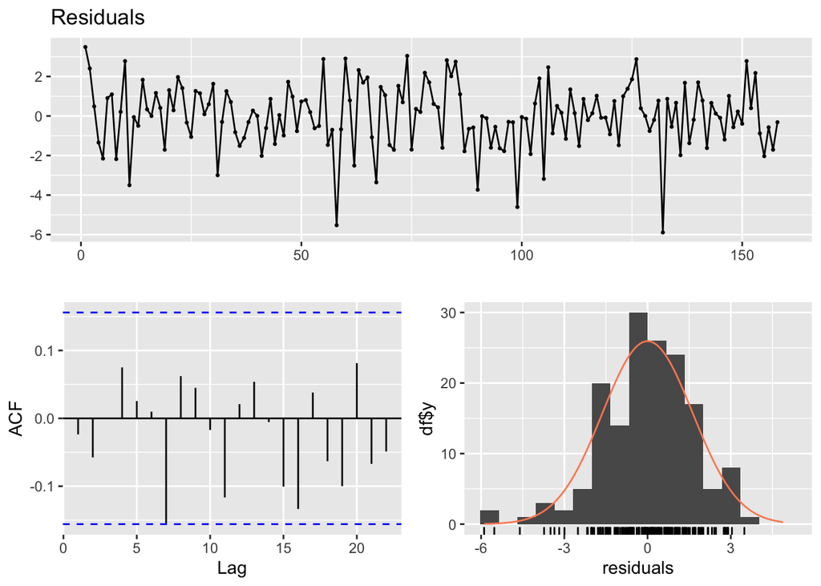

```
##
##  Breusch-Godfrey test for serial correlation of order up to 15
##
## data:  Residuals
## LM test = 15.433, df = 15, p-value = 0.4207
```

```r
checkresiduals(second.step)
```

Here, *because we’ve determined the variables are cointegrated*, each righthand-side variable is stationary and we can use standard critical values for all hypothesis tests.

We’ll talk more about interpretation below.

**Go to the second recording.**

# GECM t-test

To conduct the ECM $t$-test for cointegration, we estimate the generalized error correction model:

$$\Delta y_t = D_t -\alpha_1^* y_{t-1}-\beta_1^* x_{1t-1} - \beta_2^* x_{2t-1} - … - \beta_n^* x_{nt-1} + \psi_{1}\Delta x_{1t} + \psi_{2}\Delta x_{2t} + …, \psi_{j}\Delta x_{jt}+ \varepsilon_t$$

where we also include enough lagged changes in the variables to ensure the residuals are white noise. The GECM should also include the interventions in the static ciontegrating regression **plus** first differences of those interventions. I experimented a bit with different lag lengths of $\Delta y_t$ and found lag 1, lag 4, and lag 8 just did the trick.

$$\Delta Mood_t = D_t -\alpha_1^* Mood_{t-1}-\beta_1^* PolAvg_{1t-1} + \beta_2^*Vietnam_t + \beta_3*Hostages_t + \beta_4^*Iraq_t + \\ \psi_{1}\Delta PolAvg_{t} +
\psi_{2}\Delta Vietnam_t + \psi_{3}\Delta Hostages_t +\psi_{4}\Delta Iraq_t + \\ \psi_{4}\Delta filtbf_{t}+ \psi_{5}\Delta filtbf_{t-1}+ \psi_{6}\Delta Mood_{t-1} + \psi_{7}\Delta Mood_{t-4}+ \psi_{8}\Delta Mood_{t-8} +\varepsilon_t$$

```r
GECM <- dynlm(d(Mood)~ L(Mood)+ L(PolAvg)+
                Vietnam + Iraq + IranHost+
                d(Vietnam) + d(Iraq) + d(IranHost) +
                d(PolAvg) + L(d(PolAvg), 1) + d(filtbf) +  L(d(filtbf),1) +
                L(d(Mood),1) + L(d(Mood),4) + L(d(Mood),8)
              ,  data=data.ts2)


GECMHAC <- coeftest(GECM, vcov = vcovHAC(GECM))# Heteroscedastic and

bgtest(GECM, order =4)
```

```
##
##  Breusch-Godfrey test for serial correlation of order up to 4
##
## data:  GECM
## LM test = 4.8054, df = 4, p-value = 0.3078
```

```r
bgtest(GECM, order =8)
```

```
##
##  Breusch-Godfrey test for serial correlation of order up to 8
##
## data:  GECM
## LM test = 11.431, df = 8, p-value = 0.1785
```

```r
bgtest(GECM, order =12)
```

```
##
##  Breusch-Godfrey test for serial correlation of order up to 12
##
## data:  GECM
## LM test = 14.71, df = 12, p-value = 0.2577
```

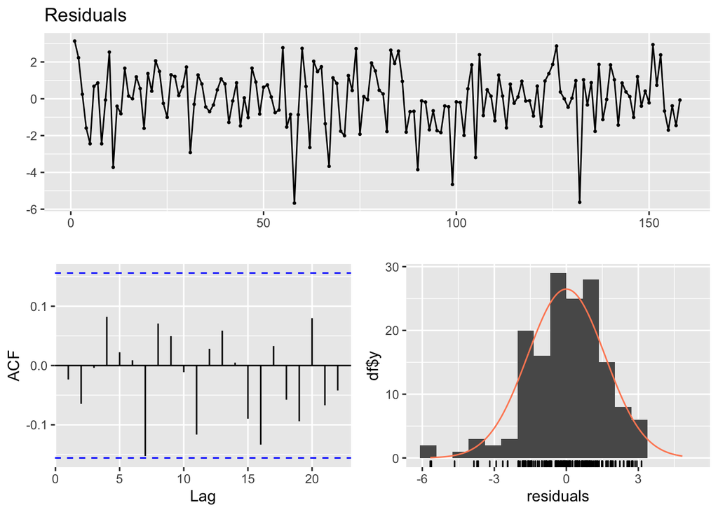

```
##
##  Breusch-Godfrey test for serial correlation of order up to 19
##
## data:  Residuals
## LM test = 21.845, df = 19, p-value = 0.2921
```

```r
checkresiduals(GECM)
```

Let’s look at the results. I’ve asked `stargazer()` to print the $t$-statistics, since this is our test statistic.

```r
stargazer(GECMHAC, type="text",
          dep.var.labels = "Changes in Mood",
          report = "vct*",
          column.labels = "GECM")
```

```
##
## ===========================================
##                     Dependent variable:
##                 ---------------------------
##                       Changes in Mood
##                            GECM
## -------------------------------------------
## L(Mood)                   -0.298
##                        t = -5.131***
##
## L(PolAvg)                 -0.117
##                        t = -2.803***
##
## Vietnam                    2.720
##                        t = 3.612***
##
## Iraq                       1.372
##                        t = 3.127***
##
## IranHost                  -1.614
##                        t = -3.059***
##
## d(Vietnam)                -2.022
##                        t = -2.899***
##
## d(Iraq)                    5.536
##                        t = 14.535***
##
## d(IranHost)                0.911
##                          t = 1.123
##
## d(PolAvg)                 -0.125
##                         t = -0.631
##
## L(d(PolAvg), 1)           -0.107
##                         t = -0.690
##
## d(filtbf)                  0.044
##                          t = 0.886
##
## L(d(filtbf), 1)           -0.044
##                         t = -1.080
##
## L(d(Mood), 1)             -0.046
##                         t = -0.630
##
## L(d(Mood), 4)              0.151
##                          t = 1.590
##
## L(d(Mood), 8)              0.094
##                          t = 1.258
##
## Constant                  22.796
##                        t = 5.222***
##
## ===========================================
## ===========================================
## Note:           *p<0.1; **p<0.05; ***p<0.01
```

Our test statistic is the $t$-statistic on $\hat{\alpha_1^*}$ in the GECM (the coefficient on lagged **Mood**) and is -5.131

## Critical Values for the GECM $t$-test

Our interest in this test regression is on the t-statistic on lagged **Mood**, $\alpha_1^*$. But is has a non-standard limiting distribution. If our GECM did not contain the levels intervention variables, we could use MacKinnon’s 2002 tables. *This paper is in Canvas*. For practice, we will calculate them here, but also simulate them to account for the interventions. Our GECM does not contain a trend but does contain a constant, so we will use table 3. We select the row for k=2 (two $I(1)$ variables in our regression). We will use the 0.05 critical value

$$-3.2145 -3.21/161 -2.0/(161^2) -65/(161^3) = -3.234531$$

The $t$-statistic on $\hat{\alpha_1^*}$ in the GECM (the coefficient on lagged **Mood**) is -5.131, which is further from zero than the critical value. We could reject the null of no cointegration if there were not interventions. To see whether our conclusion is the same with interventions we again need to simulate the limiting distribution.

We generate the data in the same manner as above, but now estimate the GECM and harvest the $t$-statistic on lagged **Mood**. First we will estimate the MacKinnon case with no interventions and compare with the asymptotic value from MacKinnon: -3.2145.

```r
gecmt.values <- function(nsim, T){
    pb <- txtProgressBar(min = 0,      # Minimum value of the progress bar
                     max = nsim, # Maximum value of the progress bar
                     style = 3,    # Progress bar style (also available style = 1 and style = 2)
                     width = 50,   # Progress bar width. Defaults to getOption("width")
                     char = "=")   # Character used to create the bar

  out <- vector(mode="list", length=nsim)
  for(m in 1:nsim){
  x1 <- gen.unit.root(n=T)
  y <- gen.unit.root(n=T)
  y.diff <- tsdiff(y)
  x1.diff <- tsdiff(x1)
   y.lag <- tslag(y)
  x1.lag <- tslag(x1)
lm.df <- summary(lm(y.diff~ y.lag + x1.lag + x1.diff ))
    t.df <- lm.df$coefficients[,3][[2]]
    out[[m]] <- t.df
    #setTxtProgressBar(pb, m)
  }
  unlist(out)
}

outGECM1 <- gecmt.values(10000, T= 15000)
```

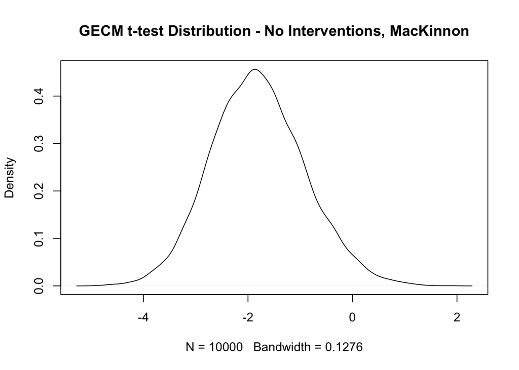

```r
plot(density(unlist(outGECM1)),main="GECM t-test Distribution - No Interventions, MacKinnon")
```

```r
GECM.MacKinnon <- quantile(outGECM1,c(.01,.025,.05,.1))

GECM.MacKinnon
```

```
##        1%      2.5%        5%       10%
## -3.799433 -3.489800 -3.217171 -2.915272
```

```r
gecmt.valuesMood <- function(nsim, T){
    pb <- txtProgressBar(min = 0,      # Minimum value of the progress bar
                     max = nsim, # Maximum value of the progress bar
                     style = 3,    # Progress bar style (also available style = 1 and style = 2)
                     width = 50,   # Progress bar width. Defaults to getOption("width")
                     char = "=")   # Character used to create the bar

  out <- vector(mode="list", length=nsim)
  for(m in 1:nsim){
  x1 <- gen.unit.root(n=T)
  Vietnam <- data$Vietnam[1:T]
  Hostages <- data$IranHost[1:T]
  Iraq <- data$Iraq[1:T]
  V.diff <- tsdiff(Vietnam)
  H.diff <- tsdiff(Hostages)
  I.diff <- tsdiff(Iraq)
  y <- gen.y(T,V.diff, H.diff, I.diff)
  y.diff <- tsdiff(y)
  x1.diff <- tsdiff(x1)
  y.lag <- tslag(y)
  x1.lag <- tslag(x1)
  lm.df <- summary(lm(y.diff~ y.lag + x1.lag  + x1.diff + Vietnam + Hostages + Iraq + V.diff + H.diff + I.diff))
  t.df <- lm.df$coefficients[,3][[2]]
  out[[m]] <- t.df
    #setTxtProgressBar(pb, m)
  }
  unlist(out)
}

outGECM2Mood <- gecmt.valuesMood(50000, T=168)
```

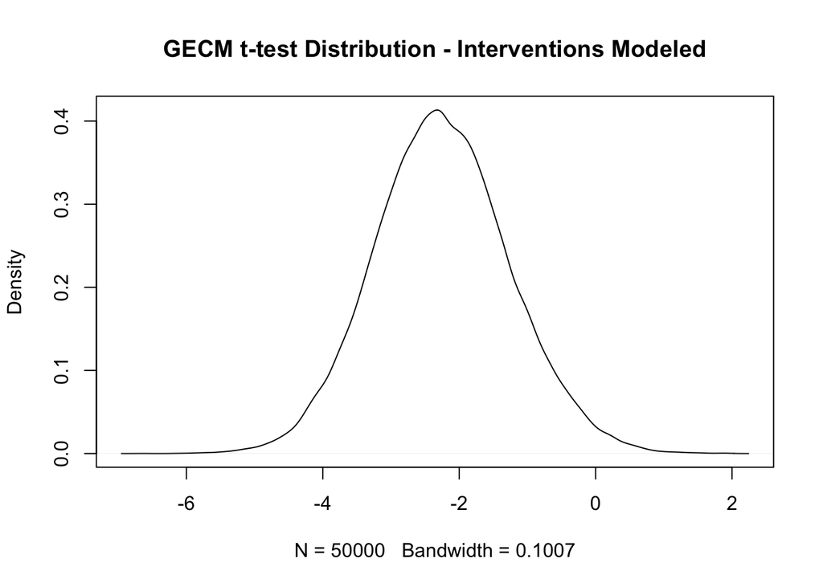

```r
plot(density(unlist(outGECM2Mood)),main="GECM t-test Distribution - Interventions Modeled")
```

```r
GECM.Modeled.Interventions <- quantile(outGECM2Mood,c(.01,.025,.05,.1))
GECM.Modeled.Interventions
```

```
##        1%      2.5%        5%       10%
## -4.499433 -4.146565 -3.842294 -3.491063
```

```r
stargazer(GECMHAC, type = "text",
          title="Cointegration Error Correction Models",
          dep.var.labels="Changes in Mood",
          dep.var.caption = "",
          model.names = FALSE,
          column.labels="GECM")
```

```
##
## Cointegration Error Correction Models
## ===========================================
##                       Changes in Mood
##                            GECM
## -------------------------------------------
## L(Mood)                  -0.298***
##                           (0.058)
##
## L(PolAvg)                -0.117***
##                           (0.042)
##
## Vietnam                  2.720***
##                           (0.753)
##
## Iraq                     1.372***
##                           (0.439)
##
## IranHost                 -1.614***
##                           (0.528)
##
## d(Vietnam)               -2.022***
##                           (0.698)
##
## d(Iraq)                  5.536***
##                           (0.381)
##
## d(IranHost)                0.911
##                           (0.811)
##
## d(PolAvg)                 -0.125
##                           (0.197)
##
## L(d(PolAvg), 1)           -0.107
##                           (0.156)
##
## d(filtbf)                  0.044
##                           (0.049)
##
## L(d(filtbf), 1)           -0.044
##                           (0.041)
##
## L(d(Mood), 1)             -0.046
##                           (0.073)
##
## L(d(Mood), 4)              0.151
##                           (0.095)
##
## L(d(Mood), 8)              0.094
##                           (0.075)
##
## Constant                 22.796***
##                           (4.366)
##
## ===========================================
## ===========================================
## Note:           *p<0.1; **p<0.05; ***p<0.01
```

We can draw inferences directly from this model. Here, like in the Engle-Granger Two-Step approach, *because we’ve determined the variables are cointegrated*, each righthand-side variable is stationary and we can use standard critical values for all hypothesis tests. Specifically, we can normalize the long-run relationship with respect to any element of $\mathbf{X_{t-1}}$, as well as $y_{t-1}$, to show that each $\beta_{j1}$ is a coefficient on a mean-zero stationary variable and thus that standard limiting distributions apply.

# Interpretation

We can ask the same questions of either model that we did in the stationary case:

- What is the Direct Effect of a Unit Change in $x_t$ (**PolAvg**) on $y_t$ (**Mood**)?
- What is the Total Effect (LRM) of a Unit Change in $x_{t}$ (**PolAvg)** on $y_{t}$ (**Mood**)?
- What is the Long-Run Equilibrium?
- How Quickly Does $y_{t}$ (**Mood**) Change to Restore Equilibrium Following a Change in $x_{t}$ (**PolAvg)**
- How do the effects play out over time?
  - How Long Before Most of the Effect Plays Out?
  - How Long Before the Effect has Effectively Dissipated?

Let’s answer these questions and compare the results from the two-step ECM and the GECM.

First, let’s look at the results from both approaches.

```r
stargazer(mystatic2, second.step, GECMHAC, type = "text",
          dep.var.labels=c("Mood", "Changes in Mood", "Changes in Mood"),
          dep.var.caption = "",
          model.names = FALSE,
          column.labels=c("Cointegrating Regression", "Two-Step ECM", "GECM"))
```

```
##
## ====================================================================================
##                               Mood               Changes in Mood     Changes in Mood
##                     Cointegrating Regression      Two-Step ECM            GECM
##                               (1)                      (2)                 (3)
## ------------------------------------------------------------------------------------
## PolAvg                     -0.312***
##                             (0.057)
##
## L(Mood)                                                                 -0.298***
##                                                                          (0.058)
##
## L(PolAvg)                                                               -0.117***
##                                                                          (0.042)
##
## IranHost                   -4.260***                                    -1.614***
##                             (1.111)                                      (0.528)
##
## Vietnam                     9.518***                                    2.720***
##                             (0.643)                                      (0.753)
##
## Iraq                        5.336***                                    1.372***
##                             (0.531)                                      (0.439)
##
## L(DOLS.DISEQ)                                       -0.294***
##                                                      (0.059)
##
## d(Vietnam)                                            0.412             -2.022***
##                                                      (1.755)             (0.698)
##
## d(IranHost)                                          -0.371               0.911
##                                                      (1.579)             (0.811)
##
## d(Iraq)                                             6.981***            5.536***
##                                                      (1.740)             (0.381)
##
## d(PolAvg)                                            -0.084              -0.125
##                                                      (0.180)             (0.197)
##
## d(filtbf)                                             0.042               0.044
```

[output cut: 13 more lines]

```
##
## L(d(Mood), 8)                                         0.101               0.094
##                                                      (0.071)             (0.075)
##
## Constant                   72.375***                 -0.078             22.796***
##                             (2.887)                  (0.135)             (4.366)
##
## ------------------------------------------------------------------------------------
## Observations                  167                      158
## R2                           0.686                    0.294
## Adjusted R2                  0.678                    0.241
## Residual Std. Error     2.582 (df = 162)        1.689 (df = 146)
## F Statistic         88.322*** (df = 4; 162)  5.523*** (df = 11; 146)
## ====================================================================================
## Note:                                                    *p<0.1; **p<0.05; ***p<0.01
```

## Direct Effects

The direct effects of the regressors is given by the coefficients on changes in both the ECM and GECM in columns 2 and 3. Although the two methods are asymptotically equivalent, the coefficients in finite samples will differ, sometimes by quite a bit.

- The contemporaneous direct effect of **PolAvg** is given by -0.084 in the ECM and -0.125 in the GECM. The immediate change in **Mood** with a one-unit increase in in the generosity of policy leads to a drop of 0.084 or 0.125 in **Mood** in the same period.
- The direct effect of **filtbf** is given by 0.042 in the ECM and 0.044 in the GECM. A one-unit increase in economic expectations leads to a positive change in **Mood** of about .04 in either model.
- The direct effect of involvement in Vietnam is quite different in the two models. It is not distinguishable from zero in the ECM but negative and significant in the GECM. When Vietnam began, **Mood** became more conservative.

## Long-run Multipliers

Two Step: Coefficients on levels of $I(1)$ regressors in CI regression:
$$y_t = \hat{D}_{lr} +\hat{\lambda}_{1} x_{1t} + \hat{\lambda}_{2} x_{2t} + ...+ \hat{\lambda}_{j} x_{jt}$$

In our example $\hat{\lambda}$:
$$Mood_t = \hat{\lambda_0} + \hat{\lambda}_{V} Vietnam_t + \hat{\lambda}_H Hostages_t + \hat{\lambda}_I Iraq_t +\hat{\lambda}_{1} PolAvg_{1t}$$

Or:

$$Mood_t = 72.38+ 9.52 Vietnam_t - 4.26 Hostages_t + 5.34 Iraq_t - 0.31 PolAvg_{1t}$$

The long-run multiplier for **PolAvg** is -0.31. Every point increase in the generosity of public policy leads to a decrease in the preference for my liberal policies of 0.31.

The long-run multiplier for **Vietnam** is 9.52, for **Hostages** is -4.26, and for **Iraq** is 5.34.

GECM:

$$-\frac{\hat{\beta}_{j}^*}{\hat{\alpha}_1^*}x_{jt-1}$$

For **PolAvg**: $-(-0.117/-0.298)=-0.393$

For **Vietnam**: $-(2.72/-0.298)=9.128$

For Iraq: $-(1.37/-0.298)=4.597$

The LRM differ slightly in sample.

## Long-run Equilibrium

Whereas in the stationary case, the equilibrium is a fixed point, in the cointegrated case, the equilibrium is moving over time:

Two Step: CI regression from step 1:

$$y_t = \hat{D}_{lr} + \hat{\lambda}_{1} x_{1t} + \hat{\lambda}_{2} x_{2t} + ... + \hat{\lambda}_{j} x_{jt}$$

In our example:

$$Mood_t = \hat{\lambda_0} + \hat{\lambda}_{V} Vietnam + \hat{\lambda}_H Hostages + \hat{\lambda} Iraq +\hat{\lambda}_{1} PolAvg_{t}$$

or:

$$Mood_t = 72.38+ 9.52 Vietnam_t - 4.26 Hostages_t + 5.34 Iraq_t - 0.31 PolAvg_{t}$$

GECM:

$$y_t = \frac{\hat{\alpha}_0^*}{-\hat{\alpha}_1^*} + \frac{\hat{\delta}}{-\hat{\alpha}_1^*} t+ \frac{\sum_{j=1}^{n} \hat{\beta}_{j1}^* x_{jt}}{-\hat{\alpha}_1^*}$$

Or:

Let’s calculate the moving equilibrium from both approaches.

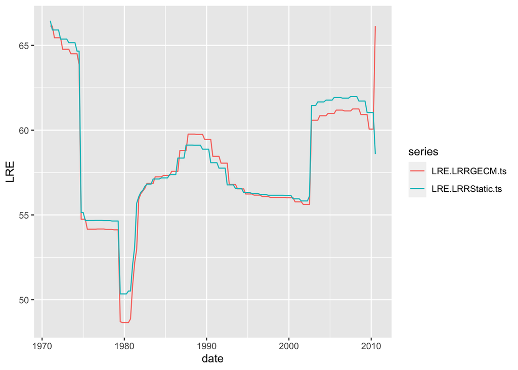

```r
#Long-run relationship from GECM
LRRGECM <- GECM$coefficients[1]/(-GECM$coefficients[2]) +
  GECM$coefficients[3]*model.frame(GECM)$"L(PolAvg)"/(-GECM$coefficients[2]) +
  GECM$coefficients[4]*model.frame(GECM)$Vietnam/(-GECM$coefficients[2])+
  GECM$coefficients[5]*model.frame(GECM)$Iraq/(-GECM$coefficients[2])+
  GECM$coefficients[6]*model.frame(GECM)$IranHost/(-GECM$coefficients[2])
LRRGECM.ts <- ts(LRRGECM, start = c(1971,1), end = c(2010,3), frequency = 4)

#Long-run relationship from First step of Two-Step Approach
LRRStatic.ts <- ts(mystatic2$fitted.values, start = c(1968,4), end = c(2010,3), frequency = 4)

#Combine the two over shared time period
LRE <- ts.union(LRRGECM.ts, LRRStatic.ts)
LRE <- na.omit(LRE)
#Put the two equilibria in a data frame and graph
LREdata <-data.frame(LRE=as.matrix(LRE), date=time(LRE))
LRE.longer <- pivot_longer(LREdata, cols= -date, names_to="series", values_to="LRE")
ggplot(LRE.longer, aes(x=date, y = LRE, color = series)) +
  geom_line()
```

```r
cor(LRE)
```

```
##              LRRGECM.ts LRRStatic.ts
## LRRGECM.ts    1.0000000    0.9729252
## LRRStatic.ts  0.9729252    1.0000000
```

The equilibria are highly correlated. Where they differ is in the onset of the interventions. This happens because the effects of the interventions in the GECM are conditional on the short-run dynamics, whereas they are not in the cointegrating regression. The dynamics in the GECM are going to be estimated “better.”

## How Quickly Does $y_{t}$ Change to Restore Equilibrium Following a Change in $x_{t}$

Two Step: The error correction rate is given by the coefficient on lagged residuals from CI regression, $\hat{\gamma}$:

$$\Delta y_t=\hat{D}_{sr} +\hat{\gamma} (\hat{\mu}_{t-1})+ \hat{\psi}_{1}\Delta x_{1t} + \hat{\psi}_{2}\Delta x_{2t} + …+\hat{\psi}_{j}\Delta x_{jt}$$

In our example:

$$\Delta Mood_t= -0.08 -0.294 (\hat{\mu}_{t-1})+ 0.412\Delta Vietnam_t - 0.37 \Delta Hostages_t + 6.98 \Delta Iraq_t - 0.09\Delta PolAvg_t \\+ 0.04\Delta filtbf_t - 0.04 \Delta Mood_{t-1} + 0.16 \Delta Mood_{t-4} + 0.10 \Delta Mood_{t-8}$$

$\hat{\gamma}=-0.294$.

GECM: The error correction rate is given by the coefficient on lagged $y_{t-1}$, $\hat{\alpha}_1^*$.

$$\Delta y_t = \hat{D}_t -\hat{\alpha_1}^* y_{t-1}-\hat{\beta}_1^* x_{1t-1} - \hat{\beta}_2^* x_{2t-1} - … - \hat{\beta}_n^* x_{nt-1} + \hat{\psi}_{1}\Delta x_{1t} + \hat{\psi}_{2}\Delta x_{2t} + …, \hat{\psi}_{j}\Delta x_{jt}$$

In our example:

$\hat{\alpha}_1^*=-0.298$.

In either model, about 29% of the disequilibrium is corrected in each period.

## Impulse Response Functions

We want to know how $y_t$ adjusts to return to equilibrium after a one-unit **step** increase in $x_t$. Say, **PolAvg** increase permanently by one unit: Assume a one time change in **PolAvg**, such that $\Delta PolAvg_t=1$ at time $t$ and that $Mood_{t-1}=0$.

Then calculate the path of **Mood** in each successive period. This can be tricky, especially (as here) when there are long lags of $\Delta y_t$ in the model.

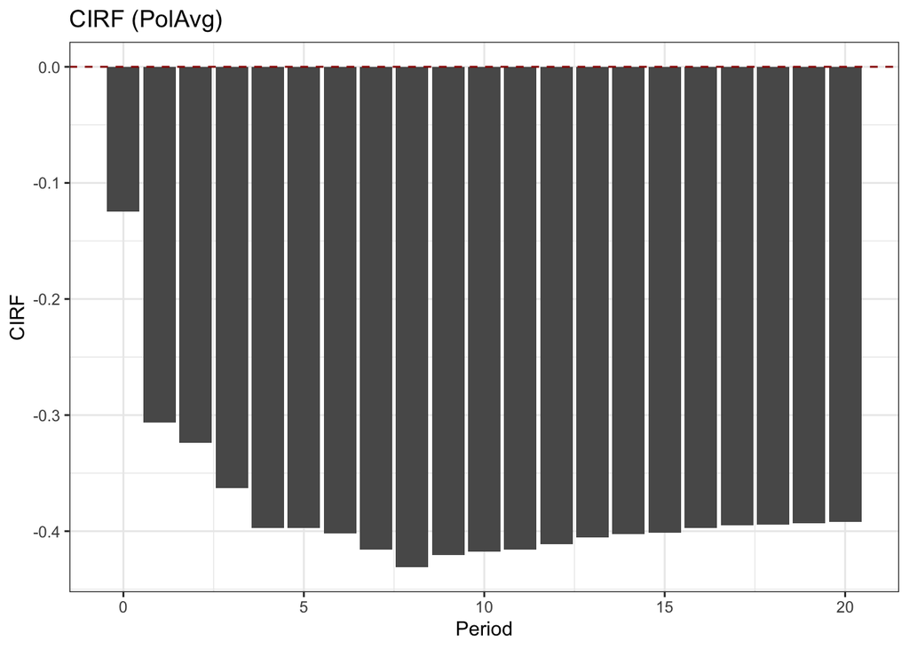

```r
PolAvg.cirf <- data.frame(period = c(0:20),
                           PolAvgcIRF = NA_real_)

#GECM$coefficients[2] = Lag Mood = -0.3031263
#GECM$coefficients[3] = Lag PolAvg = -0.1165336  * 1 every period after zero
#GECM$coefficients[10] = Delta PolAvg = -0.07515562  * 1 only at zero period
#GECM$coefficients[11] = Lag Delta PolAvg = -0.1455531 * 1 only at first period
#GECM$coefficients[14] = Lag Delta Mood = -0.05470087
#GECM$coefficients[15] = Lag 4 Delta Mood =  0.1617978
#GECM$coefficients[16] =  Lag 8 Delta Mood = 0.06149369

#Zero period
PolAvg.cirf$PolAvgcIRF[1] <- (1 + GECM$coefficients[2])*0 + GECM$coefficients[3]*0 + GECM$coefficients[10]*1 +  GECM$coefficients[11]*0 + GECM$coefficients[14]*0 + GECM$coefficients[15]*0 + GECM$coefficients[16]*0

#First period after shock
PolAvg.cirf$PolAvgcIRF[2] <- (1 + GECM$coefficients[2])*PolAvg.cirf$PolAvgcIRF[1] + GECM$coefficients[3]*1 + GECM$coefficients[10]*0 +  GECM$coefficients[11]*1 +
GECM$coefficients[14]*PolAvg.cirf$PolAvgcIRF[1] + GECM$coefficients[15]*0 + GECM$coefficients[16]*0

#Second period after shock
PolAvg.cirf$PolAvgcIRF[3] <- (1 + GECM$coefficients[2])*PolAvg.cirf$PolAvgcIRF[2] + GECM$coefficients[3]*1 + GECM$coefficients[10]*0 +  GECM$coefficients[11]*0 +
GECM$coefficients[14]*(PolAvg.cirf$PolAvgcIRF[2]-PolAvg.cirf$PolAvgcIRF[1]) + GECM$coefficients[15]*0 + GECM$coefficients[16]*0

#Third period after shock
PolAvg.cirf$PolAvgcIRF[4] <- (1 + GECM$coefficients[2])*PolAvg.cirf$PolAvgcIRF[3] + GECM$coefficients[3]*1 + GECM$coefficients[10]*0 +  GECM$coefficients[11]*0 +
GECM$coefficients[14]*(PolAvg.cirf$PolAvgcIRF[3]-PolAvg.cirf$PolAvgcIRF[2]) + GECM$coefficients[15]*PolAvg.cirf$PolAvgcIRF[1] + GECM$coefficients[16]*0

#Fourth period after shock
PolAvg.cirf$PolAvgcIRF[5] <- (1 + GECM$coefficients[2])*PolAvg.cirf$PolAvgcIRF[4] + GECM$coefficients[3]*1 + GECM$coefficients[10]*0 +  GECM$coefficients[11]*0 +
GECM$coefficients[14]*(PolAvg.cirf$PolAvgcIRF[4]-PolAvg.cirf$PolAvgcIRF[3]) + GECM$coefficients[15]*(PolAvg.cirf$PolAvgcIRF[2]-PolAvg.cirf$PolAvgcIRF[1]) + GECM$coefficients[16]*0

#Fifth period after shock
PolAvg.cirf$PolAvgcIRF[6] <- (1 + GECM$coefficients[2])*PolAvg.cirf$PolAvgcIRF[5] + GECM$coefficients[3]*1 + GECM$coefficients[10]*0 +  GECM$coefficients[11]*0 +
GECM$coefficients[14]*(PolAvg.cirf$PolAvgcIRF[5]-PolAvg.cirf$PolAvgcIRF[4]) + GECM$coefficients[15]*(PolAvg.cirf$PolAvgcIRF[3]-PolAvg.cirf$PolAvgcIRF[2])+ GECM$coefficients[16]*0

#Sixth period after shock
PolAvg.cirf$PolAvgcIRF[7] <- (1 + GECM$coefficients[2])*PolAvg.cirf$PolAvgcIRF[6] + GECM$coefficients[3]*1 + GECM$coefficients[10]*0 +  GECM$coefficients[11]*0 +
GECM$coefficients[14]*(PolAvg.cirf$PolAvgcIRF[6]-PolAvg.cirf$PolAvgcIRF[5]) + GECM$coefficients[15]*(PolAvg.cirf$PolAvgcIRF[4]-PolAvg.cirf$PolAvgcIRF[3]) + GECM$coefficients[16]*0

#Seventh period after shock
PolAvg.cirf$PolAvgcIRF[8] <- (1 + GECM$coefficients[2])*PolAvg.cirf$PolAvgcIRF[7] + GECM$coefficients[3]*1 + GECM$coefficients[10]*0 +  GECM$coefficients[11]*0 +
GECM$coefficients[14]*(PolAvg.cirf$PolAvgcIRF[7]-PolAvg.cirf$PolAvgcIRF[6]) + GECM$coefficients[15]*(PolAvg.cirf$PolAvgcIRF[5]-PolAvg.cirf$PolAvgcIRF[4]) + GECM$coefficients[16]*PolAvg.cirf$PolAvgcIRF[1]

#Periods 8+ after shock
for (t in 9:21) {
PolAvg.cirf$PolAvgcIRF[t] <-(1 + GECM$coefficients[2])*PolAvg.cirf$PolAvgcIRF[t-1] + GECM$coefficients[3]*1 + GECM$coefficients[10]*0 +  GECM$coefficients[11]*0 +
GECM$coefficients[14]*(PolAvg.cirf$PolAvgcIRF[t-1]-PolAvg.cirf$PolAvgcIRF[t-2]) + GECM$coefficients[15]*(PolAvg.cirf$PolAvgcIRF[t-4]-PolAvg.cirf$PolAvgcIRF[t-5]) + GECM$coefficients[16]*(PolAvg.cirf$PolAvgcIRF[t-7]-PolAvg.cirf$PolAvgcIRF[t-8])

  }


#### Plot
ggplot(data = PolAvg.cirf, aes(x = period, y = PolAvgcIRF)) +
               geom_bar(stat = "identity") +
               geom_hline(aes(yintercept = 0),
                          colour = "#990000",
                          linetype = "dashed") +
               ylab("CIRF") +
               xlab("Period") +
               ggtitle("CIRF (PolAvg)") +
               theme_bw()
```

Here we see that when policy became one point more expansive/generous, preferences for more expansive/liberal policy declined over time, eventually reaching the LRM of 0.393 points more conservative.

The effect in changes in **Mood** is the same as the period-to-period effects. In the code below, I calculate the immediate effect as the zero period effect. All remaining periods take the current effect from the previous IRFs and subtract the previous period. That is I difference the cumulative effect on levels from above and get changes.

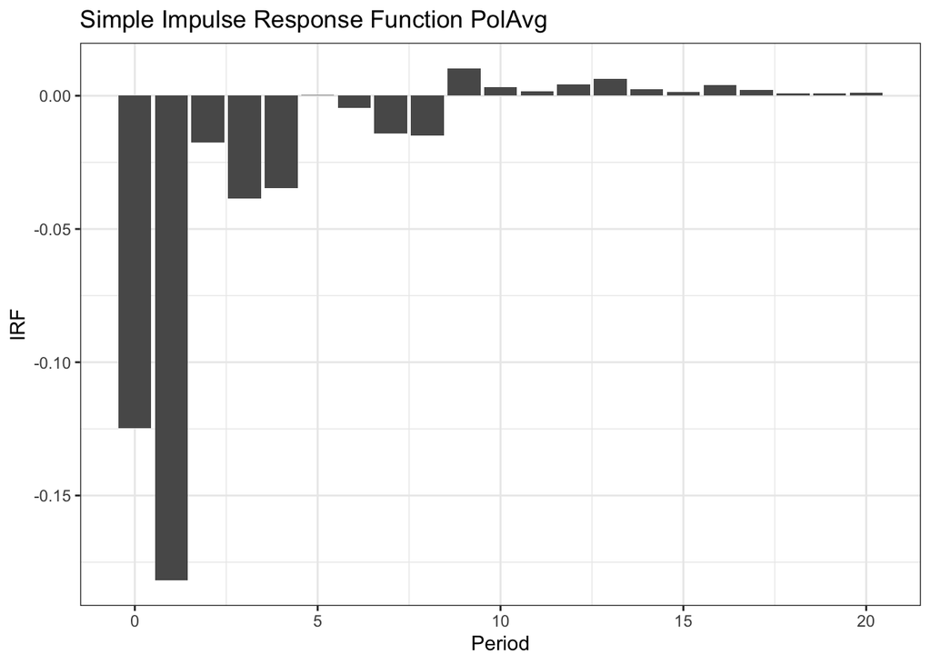

```r
PolAvg.irf <- data.frame(period = c(0:20),
                           PolAvgIRF = NA_real_)

#Zero period
PolAvg.irf$PolAvgIRF[1] <- (1 + GECM$coefficients[2])*0 + GECM$coefficients[3]*0 + GECM$coefficients[10]*1 +  GECM$coefficients[11]*0 + GECM$coefficients[14]*0 + GECM$coefficients[15]*0 + GECM$coefficients[16]*0

currentvalue <- PolAvg.irf$PolAvgIRF[1]
#Rest of periods
for (t in 2:21) {
    PolAvg.irf$PolAvgIRF[t] <- PolAvg.cirf$PolAvgcIRF[t] - PolAvg.cirf$PolAvgcIRF[t-1]
    currentvalue <- PolAvg.irf$PolAvgIRF[t]
}
ggplot(data = PolAvg.irf, aes(x = period,y = PolAvgIRF)) +
                geom_bar(stat = "identity") +
                ylab("IRF") +
                xlab("Period") +
                ggtitle("Simple Impulse Response Function PolAvg") +
                theme_bw()
```

Here we see the biggest effects on Mood were in the first and second period, and then generally decay, although the lagged differences of **Mood** in the model interrupt the general pattern.